# MortgageNationLevel

### Loading Modules & Libraries

```python
import pandas as pd
import numpy as np
import cufflinks as cf
import plotly as py
import plotly.graph_objs as go
import ipywidgets as widgets
from scipy import special
import matplotlib.pyplot as plt
import seaborn as sns
import math
from IPython.display import Markdown, display ,HTML
import statsmodels.api as sm # import API
from matplotlib.pyplot import xticks
sns.set(style="whitegrid")
pd.set_option('display.max_columns', 100)
py.offline.init_notebook_mode(connected=True) # plotting in offilne mode
cf.set_config_file(offline=False, world_readable=True, theme='ggplot')
pd.set_option('display.max_colwidth', None) # make sure data and columns are displayed correctly without purge
pd.options.display.float_format = '{:20,.2f}'.format # display float value with correct precision
import warnings
warnings.filterwarnings('ignore')
%matplotlib inline
```

### Meta Data Helper Utilities

```python
def log(string):
    display(Markdown("> <span style='color:blue'>"+string+"</span>"))
```

```python
def header(string):
    display(Markdown("------ "))
    display(Markdown("### "+string))
```

```python
def header_red(string):
    display(Markdown("> <span style='color:red'>"+string))
```

```python
def color_red(val):
    color = 'red' if val > 65 else 'black'
    return 'color: %s' % color
```

```python
def get_variable_type(element) :
    if element==0:
        return "Not Known"
    elif element >2 and element < 20:
        return "Categorical"
    elif element >= 20 and element!=0 :
        return "Contineous"
```

```python
def predict_variable_type(metadata_matrix):
    metadata_matrix["Variable_Type"] = metadata_matrix["Unique_Values_Count"].apply(get_variable_type).astype(str)
    metadata_matrix["frequency"] = metadata_matrix["Null_Count"] - metadata_matrix["Null_Count"]
    metadata_matrix["frequency"].astype(int)
    return metadata_matrix
```

```python
def get_meta_data(dataframe) :
    metadata_matrix = pd.DataFrame({
                    'Datatype' : dataframe.dtypes.astype(str),
                    'Non_Null_Count': dataframe.count(axis = 0).astype(int),
                    'Null_Count': dataframe.isnull().sum().astype(int),
                    'Null_Percentage': dataframe.isnull().sum()/len(dataframe) * 100,
                    'Unique_Values_Count': dataframe.nunique().astype(int)
                     })
    metadata_matrix = predict_variable_type(metadata_matrix)
    return metadata_matrix
```

```python
def display_columns_with_1_unique_value(dataframe):
    unique_values_count_1 = dataframe[dataframe["Unique_Values_Count"] == 1]
    drop_value_col = unique_values_count_1.index.tolist()
    lenght = len(drop_value_col)
    header("Columns with only one unique value : "+str(lenght))
    if lenght == 0 :
        header_red("No columns with only one unique values.")
    else :
        for index,item in enumerate(drop_value_col) :
            print(index,".",item)
```

```python
def list_potential_categorical_type(dataframe,main) :
    header("Stats for potential Categorical datatype columns")
    metadata_matrix_categorical = dataframe[dataframe["Variable_Type"] == "Categorical"]
    # TO DO *** Add check to skip below if there is no Categorical values
    length = len(metadata_matrix_categorical)
    if length == 0 :
        header_red("No Categorical columns in given dataset.")
    else:
        metadata_matrix_categorical = metadata_matrix_categorical.filter(["Datatype","Unique_Values_Count"])
        metadata_matrix_categorical.sort_values(["Unique_Values_Count"], axis=0,ascending=False, inplace=True)
        col_to_check = metadata_matrix_categorical.index.tolist()
        name_list = []
        values_list = []
        for name in col_to_check :
            name_list.append(name)
            values_list.append(main[name].unique())
        temp = pd.DataFrame({"index":name_list,"Unique_Values":values_list})
        metadata_matrix_categorical = metadata_matrix_categorical.reset_index()
        metadata_matrix_categorical = pd.merge(metadata_matrix_categorical,temp,how='inner',on='index')
        display(metadata_matrix_categorical.set_index("index"))
```

```python
def get_potential_categorical_type(dataframe,main,unique_count) :
    metadata_matrix_categorical = dataframe[dataframe["Variable_Type"] == "Categorical"]
    metadata_matrix_categorical = dataframe[dataframe["Unique_Values_Count"] == unique_count]
    length = len(metadata_matrix_categorical)
    if length == 0 :
        header_red("No Categorical columns in given dataset.")
    else :
        metadata_matrix_categorical = metadata_matrix_categorical.filter(["Datatype","Unique_Values_Count"])
        metadata_matrix_categorical.sort_values(["Unique_Values_Count"], axis=0,ascending=False, inplace=True)
        col_to_check = metadata_matrix_categorical.index.tolist()
        name_list = []
        values_list = []
        for name in col_to_check :
            name_list.append(name)
            values_list.append(main[name].unique())
        temp = pd.DataFrame({"index":name_list,"Unique_Values":values_list})
        metadata_matrix_categorical = metadata_matrix_categorical.reset_index()
        metadata_matrix_categorical = pd.merge(metadata_matrix_categorical,temp,how='inner',on='index')
        display(metadata_matrix_categorical.set_index("index"))
```

```python
def plot_data_type_pie_chat(dataframe) :
    header("Stats for Datatype Percentage Distribution")
    dataframe_group = dataframe.groupby("Datatype").frequency.count().reset_index()
    dataframe_group.sort_values(["Datatype"], axis=0,ascending=False, inplace=True)
    trace = go.Pie(labels=dataframe_group["Datatype"].tolist(), values=dataframe_group["frequency"].tolist())
    layout = go.Layout(title="Datatype Percentage Distribution")
    fig = go.Figure(data=[trace], layout=layout)
    py.offline.iplot(fig)
```

```python
def pairplot(x_axis,y_axis) :
    sns.pairplot(df,x_vars=x_axis,y_vars=y_axis,height=4,aspect=1,kind="scatter")
    plt.show()
```

```python
def heatmap(x,y,dataframe):
    plt.figure(figsize=(x,y))
    sns.heatmap(dataframe.corr(),cmap="OrRd",annot=True)
    plt.show()
```

```python
def plot_box_chart(dataframe) :
    data = []
    for index, column_name in enumerate(dataframe) :
        data.append(
        go.Box(y=dataframe.iloc[:, index],name=column_name))

    layout = go.Layout(yaxis=dict(title="Frequency",zeroline=False),boxmode='group')
    fig = go.Figure(data=data, layout=layout)
    py.offline.iplot(fig)
```

```python
def bar_count_plot(dataframe,col_name) :
    plt.figure(figsize=(16,8))
    plt.title(col_name + 'Histogram')
    sns.countplot(df[col_name], palette=("plasma"))
    xticks(rotation = 90)
    plt.show()
```

```python
def color_red(val):
    color = 'red' if val > 5 else 'black'
    return 'color: %s' % color
```

```python
def color_code_vif_values(val):
    if val > 10 : color = 'red'
    elif val > 5 and val <= 10 : color = 'blue'
    elif val > 0 and val <= 5 : color = 'darkgreen'
    else : color = 'black'
    return 'color: %s' % color
```

```python
def drop_col(dataframe,col_to_drop) :
    dataframe.drop([col_to_drop],axis=1,inplace=True)
    return dataframe
```

## Loading the dataset

```python
df_train = pd.read_csv("train.csv")
df_train['Data Type']='Train'
df_test = pd.read_csv("test.csv")
df_test['Data Type']='Test'
df=pd.concat([df_train,df_test])
del df['UID']
display(df.head())
print("Dimension of the Data: ",df.shape)
```

|  | BLOCKID | SUMLEVEL | COUNTYID | STATEID | state | state_ab | city | place | type | primary | zip_code | area_code | lat | lng | ALand | AWater | pop | male_pop | female_pop | rent_mean | rent_median | rent_stdev | rent_sample_weight | rent_samples | rent_gt_10 | rent_gt_15 | rent_gt_20 | rent_gt_25 | rent_gt_30 | … |
| --- | --- | --- | --- | --- | --- | --- | --- | --- | --- | --- | --- | --- | --- | --- | --- | --- | --- | --- | --- | --- | --- | --- | --- | --- | --- | --- | --- | --- | --- | --- |
| 0 | nan | 140 | 53 | 36 | New York | NY | Hamilton | Hamilton | City | tract | 13346 | 315 | 42.84 | -75.50 | 202,183,361.00 | 1699120 | 5230 | 2612 | 2618 | 769.39 | 784.00 | 232.64 | 272.34 | 362.00 | 0.87 | 0.79 | 0.59 | 0.46 | 0.43 | … |
| 1 | nan | 140 | 141 | 18 | Indiana | IN | South Bend | Roseland | City | tract | 46616 | 574 | 41.70 | -86.27 | 1,560,828.00 | 100363 | 2633 | 1349 | 1284 | 804.88 | 848.00 | 253.47 | 312.59 | 513.00 | 0.97 | 0.93 | 0.70 | 0.70 | 0.55 | … |
| 2 | nan | 140 | 63 | 18 | Indiana | IN | Danville | Danville | City | tract | 46122 | 317 | 39.79 | -86.52 | 69,561,595.00 | 284193 | 6881 | 3643 | 3238 | 742.77 | 703.00 | 323.39 | 291.86 | 378.00 | 0.95 | 0.89 | 0.80 | 0.67 | 0.39 | … |
| 3 | nan | 140 | 127 | 72 | Puerto Rico | PR | San Juan | Guaynabo | Urban | tract | 927 | 787 | 18.40 | -66.10 | 1,105,793.00 | 0 | 2700 | 1141 | 1559 | 803.42 | 782.00 | 297.39 | 259.30 | 368.00 | 0.95 | 0.87 | 0.70 | 0.62 | 0.51 | … |
| 4 | nan | 140 | 161 | 20 | Kansas | KS | Manhattan | Manhattan City | City | tract | 66502 | 785 | 39.20 | -96.57 | 2,554,403.00 | 0 | 5637 | 2586 | 3051 | 938.56 | 881.00 | 392.44 | 1,005.43 | 1,704.00 | 0.99 | 0.98 | 0.92 | 0.85 | 0.78 | … |

```
Dimension of the Data:  (39030, 80)
```

```python
df.info()
```

```
<class 'pandas.core.frame.DataFrame'>
Int64Index: 39030 entries, 0 to 11708
Data columns (total 80 columns):
 #   Column                       Non-Null Count  Dtype
---  ------                       --------------  -----
 0   BLOCKID                      0 non-null      float64
 1   SUMLEVEL                     39030 non-null  int64
 2   COUNTYID                     39030 non-null  int64
 3   STATEID                      39030 non-null  int64
 4   state                        39030 non-null  object
 5   state_ab                     39030 non-null  object
 6   city                         39030 non-null  object
 7   place                        39030 non-null  object
 8   type                         39030 non-null  object
 9   primary                      39030 non-null  object
```

[output cut: 72 more lines]

```python
del df['BLOCKID']
log('Dropping Varable BLOCKID (contains all Null)')
```

> Dropping Varable BLOCKID (contains all Null)

## Meta data analysis for loaded dataset

```python
metadata_matrix_dataframe = get_meta_data(df)

# 1. Columns List with only 1 unique values
display_columns_with_1_unique_value(metadata_matrix_dataframe)

# 2. Display Data Type percenatges
plot_data_type_pie_chat(metadata_matrix_dataframe)

# 3. Potential Categorical Variable columns
list_potential_categorical_type(metadata_matrix_dataframe,df)
```

Columns with only one unique value : 2

```
0 . SUMLEVEL
1 . primary
```

Stats for Datatype Percentage Distribution

[interactive chart not shown]

Stats for potential Categorical datatype columns

| index | Datatype | Unique_Values_Count | Unique_Values |
| --- | --- | --- | --- |
| type | object | 6 | [City, Urban, Town, CDP, Village, Borough] |

```python
del df['SUMLEVEL']
del df['primary']
```

> Dropping Varable with unique values

# Understanding the Data

```python
df.head()
```

|  | COUNTYID | STATEID | state | state_ab | city | place | type | zip_code | area_code | lat | lng | ALand | AWater | pop | male_pop | female_pop | rent_mean | rent_median | rent_stdev | rent_sample_weight | rent_samples | rent_gt_10 | rent_gt_15 | rent_gt_20 | rent_gt_25 | rent_gt_30 | rent_gt_35 | rent_gt_40 | rent_gt_50 | … |
| --- | --- | --- | --- | --- | --- | --- | --- | --- | --- | --- | --- | --- | --- | --- | --- | --- | --- | --- | --- | --- | --- | --- | --- | --- | --- | --- | --- | --- | --- | --- |
| 0 | 53 | 36 | New York | NY | Hamilton | Hamilton | City | 13346 | 315 | 42.84 | -75.50 | 202,183,361.00 | 1699120 | 5230 | 2612 | 2618 | 769.39 | 784.00 | 232.64 | 272.34 | 362.00 | 0.87 | 0.79 | 0.59 | 0.46 | 0.43 | 0.19 | 0.15 | 0.13 | … |
| 1 | 141 | 18 | Indiana | IN | South Bend | Roseland | City | 46616 | 574 | 41.70 | -86.27 | 1,560,828.00 | 100363 | 2633 | 1349 | 1284 | 804.88 | 848.00 | 253.47 | 312.59 | 513.00 | 0.97 | 0.93 | 0.70 | 0.70 | 0.55 | 0.41 | 0.39 | 0.28 | … |
| 2 | 63 | 18 | Indiana | IN | Danville | Danville | City | 46122 | 317 | 39.79 | -86.52 | 69,561,595.00 | 284193 | 6881 | 3643 | 3238 | 742.77 | 703.00 | 323.39 | 291.86 | 378.00 | 0.95 | 0.89 | 0.80 | 0.67 | 0.39 | 0.39 | 0.28 | 0.16 | … |
| 3 | 127 | 72 | Puerto Rico | PR | San Juan | Guaynabo | Urban | 927 | 787 | 18.40 | -66.10 | 1,105,793.00 | 0 | 2700 | 1141 | 1559 | 803.42 | 782.00 | 297.39 | 259.30 | 368.00 | 0.95 | 0.87 | 0.70 | 0.62 | 0.51 | 0.47 | 0.36 | 0.33 | … |
| 4 | 161 | 20 | Kansas | KS | Manhattan | Manhattan City | City | 66502 | 785 | 39.20 | -96.57 | 2,554,403.00 | 0 | 5637 | 2586 | 3051 | 938.56 | 881.00 | 392.44 | 1,005.43 | 1,704.00 | 0.99 | 0.98 | 0.92 | 0.85 | 0.78 | 0.61 | 0.55 | 0.44 | … |

### Null value treatment

```python
df=df[df['hc_mortgage_mean'].notna()]

df=df.sort_values(by=['lat','lng'])

df=df.fillna(method="ffill")
display(df.head())
```

|  | COUNTYID | STATEID | state | state_ab | city | place | type | zip_code | area_code | lat | lng | ALand | AWater | pop | male_pop | female_pop | rent_mean | rent_median | rent_stdev | rent_sample_weight | rent_samples | rent_gt_10 | rent_gt_15 | rent_gt_20 | rent_gt_25 | rent_gt_30 | rent_gt_35 | rent_gt_40 | rent_gt_50 | … |
| --- | --- | --- | --- | --- | --- | --- | --- | --- | --- | --- | --- | --- | --- | --- | --- | --- | --- | --- | --- | --- | --- | --- | --- | --- | --- | --- | --- | --- | --- | --- |
| 2651 | 123 | 72 | Puerto Rico | PR | Salinas | Central Aguirre | Urban | 751 | 787 | 17.93 | -66.24 | 21,091,150.00 | 27780143 | 4497 | 2231 | 2266 | 451.78 | 401.00 | 157.60 | 180.92 | 189.00 | 1.00 | 0.83 | 0.83 | 0.66 | 0.59 | 0.59 | 0.59 | 0.50 | … |
| 22814 | 133 | 72 | Puerto Rico | PR | Santa Isabel | Jauca | Urban | 757 | 787 | 17.96 | -66.38 | 22,913,790.00 | 18678307 | 6201 | 3267 | 2934 | 657.34 | 440.00 | 459.46 | 221.92 | 304.00 | 0.88 | 0.84 | 0.68 | 0.50 | 0.41 | 0.41 | 0.41 | 0.41 | … |
| 3615 | 55 | 72 | Puerto Rico | PR | Guanica | Guánica | Urban | 653 | 787 | 17.96 | -66.94 | 24,698,929.00 | 7594540 | 2786 | 1367 | 1419 | 435.37 | 457.00 | 52.11 | 46.00 | 46.00 | 1.00 | 1.00 | 1.00 | 1.00 | 1.00 | 0.65 | 0.26 | 0.26 | … |
| 23737 | 57 | 72 | Puerto Rico | PR | Guayama | Jobos | Urban | 784 | 787 | 17.96 | -66.17 | 6,493,321.00 | 6066 | 2840 | 1230 | 1610 | 548.76 | 537.00 | 149.29 | 144.00 | 144.00 | 1.00 | 1.00 | 0.88 | 0.88 | 0.88 | 0.88 | 0.88 | 0.82 | … |
| 258 | 113 | 72 | Puerto Rico | PR | Ponce | Ponce | Urban | 731 | 787 | 17.97 | -66.61 | 3,946,834.00 | 5093745 | 4688 | 2211 | 2477 | 739.91 | 773.00 | 186.38 | 299.30 | 375.00 | 1.00 | 1.00 | 0.91 | 0.91 | 0.77 | 0.77 | 0.77 | 0.77 | … |

> Filling the missing values with the nearest location value.

### Dummy Variables

```python
def create_dummy_variable(dataframe,column_name):
    dummy_values = pd.get_dummies(dataframe[column_name],drop_first=True)
    dataframe = pd.concat([dataframe,dummy_values],axis=1)
    dataframe.drop([column_name],axis=1,inplace=True)
    return dataframe
```

```python
df.head()
```

|  | COUNTYID | STATEID | state | state_ab | city | place | type | zip_code | area_code | lat | lng | ALand | AWater | pop | male_pop | female_pop | rent_mean | rent_median | rent_stdev | rent_sample_weight | rent_samples | rent_gt_10 | rent_gt_15 | rent_gt_20 | rent_gt_25 | rent_gt_30 | rent_gt_35 | rent_gt_40 | rent_gt_50 | … |
| --- | --- | --- | --- | --- | --- | --- | --- | --- | --- | --- | --- | --- | --- | --- | --- | --- | --- | --- | --- | --- | --- | --- | --- | --- | --- | --- | --- | --- | --- | --- |
| 2651 | 123 | 72 | Puerto Rico | PR | Salinas | Central Aguirre | Urban | 751 | 787 | 17.93 | -66.24 | 21,091,150.00 | 27780143 | 4497 | 2231 | 2266 | 451.78 | 401.00 | 157.60 | 180.92 | 189.00 | 1.00 | 0.83 | 0.83 | 0.66 | 0.59 | 0.59 | 0.59 | 0.50 | … |
| 22814 | 133 | 72 | Puerto Rico | PR | Santa Isabel | Jauca | Urban | 757 | 787 | 17.96 | -66.38 | 22,913,790.00 | 18678307 | 6201 | 3267 | 2934 | 657.34 | 440.00 | 459.46 | 221.92 | 304.00 | 0.88 | 0.84 | 0.68 | 0.50 | 0.41 | 0.41 | 0.41 | 0.41 | … |
| 3615 | 55 | 72 | Puerto Rico | PR | Guanica | Guánica | Urban | 653 | 787 | 17.96 | -66.94 | 24,698,929.00 | 7594540 | 2786 | 1367 | 1419 | 435.37 | 457.00 | 52.11 | 46.00 | 46.00 | 1.00 | 1.00 | 1.00 | 1.00 | 1.00 | 0.65 | 0.26 | 0.26 | … |
| 23737 | 57 | 72 | Puerto Rico | PR | Guayama | Jobos | Urban | 784 | 787 | 17.96 | -66.17 | 6,493,321.00 | 6066 | 2840 | 1230 | 1610 | 548.76 | 537.00 | 149.29 | 144.00 | 144.00 | 1.00 | 1.00 | 0.88 | 0.88 | 0.88 | 0.88 | 0.88 | 0.82 | … |
| 258 | 113 | 72 | Puerto Rico | PR | Ponce | Ponce | Urban | 731 | 787 | 17.97 | -66.61 | 3,946,834.00 | 5093745 | 4688 | 2211 | 2477 | 739.91 | 773.00 | 186.38 | 299.30 | 375.00 | 1.00 | 1.00 | 0.91 | 0.91 | 0.77 | 0.77 | 0.77 | 0.77 | … |

#### Creating dummy variables

```python
df = create_dummy_variable(df,"type")
```

> Converting type to dummies

```python
display(df.describe())
```

|  | COUNTYID | STATEID | zip_code | area_code | lat | lng | ALand | AWater | pop | male_pop | female_pop | rent_mean | rent_median | rent_stdev | rent_sample_weight | rent_samples | rent_gt_10 | rent_gt_15 | rent_gt_20 | rent_gt_25 | rent_gt_30 | rent_gt_35 | rent_gt_40 | rent_gt_50 | universe_samples | used_samples | hi_mean | hi_median | hi_stdev | … |
| --- | --- | --- | --- | --- | --- | --- | --- | --- | --- | --- | --- | --- | --- | --- | --- | --- | --- | --- | --- | --- | --- | --- | --- | --- | --- | --- | --- | --- | --- | --- |
| count | 38,189.00 | 38,189.00 | 38,189.00 | 38,189.00 | 38,189.00 | 38,189.00 | 38,189.00 | 38,189.00 | 38,189.00 | 38,189.00 | 38,189.00 | 38,189.00 | 38,189.00 | 38,189.00 | 38,189.00 | 38,189.00 | 38,189.00 | 38,189.00 | 38,189.00 | 38,189.00 | 38,189.00 | 38,189.00 | 38,189.00 | 38,189.00 | 38,189.00 | 38,189.00 | 38,189.00 | 38,189.00 | 38,189.00 | … |
| mean | 85.64 | 28.31 | 50,160.88 | 595.35 | 37.51 | -91.32 | 124,419,162.98 | 6,105,699.91 | 4,378.02 | 2,150.18 | 2,227.84 | 1,054.37 | 1,006.91 | 394.88 | 296.57 | 549.15 | 0.96 | 0.87 | 0.74 | 0.61 | 0.50 | 0.41 | 0.35 | 0.25 | 581.13 | 534.96 | 70,601.26 | 57,704.23 | 54,604.30 | … |
| std | 98.34 | 16.44 | 29,576.53 | 232.35 | 5.58 | 16.31 | 1,155,112,928.63 | 202,977,294.56 | 2,084.81 | 1,046.75 | 1,071.74 | 434.38 | 440.59 | 187.49 | 269.15 | 455.33 | 0.06 | 0.11 | 0.14 | 0.16 | 0.16 | 0.16 | 0.15 | 0.14 | 457.38 | 443.76 | 30,124.60 | 29,132.41 | 17,483.66 | … |
| min | 1.00 | 1.00 | 601.00 | 201.00 | 17.93 | -166.77 | 8,299.00 | 0.00 | 4.00 | 0.00 | 0.00 | 159.13 | 107.00 | 18.26 | 0.34 | 3.00 | 0.00 | 0.00 | 0.00 | 0.00 | 0.00 | 0.00 | 0.00 | 0.00 | 0.00 | 0.00 | 4,999.85 | 4,790.00 | 1,825.74 | … |
| 25% | 29.00 | 13.00 | 26,801.00 | 405.00 | 33.92 | -97.82 | 1,809,262.00 | 0.00 | 2,949.00 | 1,434.00 | 1,493.00 | 743.11 | 703.00 | 263.80 | 103.06 | 223.00 | 0.94 | 0.82 | 0.66 | 0.52 | 0.40 | 0.31 | 0.24 | 0.16 | 258.00 | 217.00 | 49,298.09 | 37,485.00 | 42,226.52 | … |
| 50% | 63.00 | 28.00 | 47,802.00 | 614.00 | 38.73 | -86.63 | 4,916,599.00 | 26,759.00 | 4,100.00 | 2,001.00 | 2,086.00 | 952.64 | 897.00 | 347.55 | 222.46 | 429.00 | 0.98 | 0.89 | 0.76 | 0.62 | 0.50 | 0.41 | 0.34 | 0.24 | 464.00 | 418.00 | 64,142.20 | 51,360.00 | 52,309.92 | … |
| 75% | 109.00 | 42.00 | 77,304.00 | 801.00 | 41.36 | -79.83 | 34,140,943.00 | 519,220.00 | 5,463.00 | 2,681.00 | 2,786.00 | 1,259.21 | 1,196.00 | 475.74 | 410.88 | 745.00 | 1.00 | 0.94 | 0.84 | 0.72 | 0.61 | 0.52 | 0.44 | 0.34 | 778.00 | 726.00 | 85,897.57 | 70,839.00 | 65,340.09 | … |
| max | 840.00 | 72.00 | 99,929.00 | 989.00 | 67.07 | -65.38 | 103,951,000,000.00 | 24,532,276,414.00 | 53,812.00 | 26,562.00 | 27,250.00 | 3,962.34 | 3,972.00 | 1,720.72 | 4,112.12 | 7,634.00 | 1.00 | 1.00 | 1.00 | 1.00 | 1.00 | 1.00 | 1.00 | 1.00 | 7,634.00 | 7,336.00 | 228,588.21 | 253,857.00 | 124,534.01 | … |

```python
del_cols=['state_ab','state','STATEID','COUNTYID','zip_code','area_code','place','city']
for col in del_cols:
    del df[col]
display(df.head())
log("Deleting the unnecessary and repetitive variables")
print("Total columns left for model fitting: ",len(df.columns)-1)
```

|  | lat | lng | ALand | AWater | pop | male_pop | female_pop | rent_mean | rent_median | rent_stdev | rent_sample_weight | rent_samples | rent_gt_10 | rent_gt_15 | rent_gt_20 | rent_gt_25 | rent_gt_30 | rent_gt_35 | rent_gt_40 | rent_gt_50 | universe_samples | used_samples | hi_mean | hi_median | hi_stdev | hi_sample_weight | hi_samples | family_mean | family_median | … |
| --- | --- | --- | --- | --- | --- | --- | --- | --- | --- | --- | --- | --- | --- | --- | --- | --- | --- | --- | --- | --- | --- | --- | --- | --- | --- | --- | --- | --- | --- | --- |
| 2651 | 17.93 | -66.24 | 21,091,150.00 | 27780143 | 4497 | 2231 | 2266 | 451.78 | 401.00 | 157.60 | 180.92 | 189.00 | 1.00 | 0.83 | 0.83 | 0.66 | 0.59 | 0.59 | 0.59 | 0.50 | 324 | 189 | 21,238.86 | 14,300.00 | 20,427.89 | 1,413.28 | 1,722.00 | 25,980.13 | 19,076.00 | … |
| 22814 | 17.96 | -66.38 | 22,913,790.00 | 18678307 | 6201 | 3267 | 2934 | 657.34 | 440.00 | 459.46 | 221.92 | 304.00 | 0.88 | 0.84 | 0.68 | 0.50 | 0.41 | 0.41 | 0.41 | 0.41 | 344 | 304 | 31,721.21 | 18,982.00 | 34,182.36 | 1,423.37 | 1,897.00 | 37,454.97 | 34,110.00 | … |
| 3615 | 17.96 | -66.94 | 24,698,929.00 | 7594540 | 2786 | 1367 | 1419 | 435.37 | 457.00 | 52.11 | 46.00 | 46.00 | 1.00 | 1.00 | 1.00 | 1.00 | 1.00 | 0.65 | 0.26 | 0.26 | 164 | 46 | 17,458.22 | 13,496.00 | 15,792.34 | 765.39 | 897.00 | 20,711.01 | 16,244.00 | … |
| 23737 | 17.96 | -66.17 | 6,493,321.00 | 6066 | 2840 | 1230 | 1610 | 548.76 | 537.00 | 149.29 | 144.00 | 144.00 | 1.00 | 1.00 | 0.88 | 0.88 | 0.88 | 0.88 | 0.88 | 0.82 | 179 | 144 | 22,322.66 | 15,990.00 | 20,251.40 | 838.52 | 1,018.00 | 25,903.79 | 16,988.00 | … |
| 258 | 17.97 | -66.61 | 3,946,834.00 | 5093745 | 4688 | 2211 | 2477 | 739.91 | 773.00 | 186.38 | 299.30 | 375.00 | 1.00 | 1.00 | 0.91 | 0.91 | 0.77 | 0.77 | 0.77 | 0.77 | 546 | 319 | 32,024.03 | 23,941.00 | 39,369.65 | 1,527.39 | 1,876.00 | 40,845.84 | 31,971.00 | … |

> Deleting the unnecessary and repetitive variables

```
Total columns left for model fitting:  72
```

# Preparing Train and Test data

```python
np.random.seed(0)
df_train=df[df['Data Type']=='Train']
del df_train['Data Type']
df_test=df[df['Data Type']=='Test']
del df_test['Data Type']
```

> Segregation of test and train dataset

```python
print('Shape of Train dataset: ',df_train.shape)
print('Shape of Test dataset: ',df_test.shape)
```

```
Shape of Train dataset:  (26748, 72)
Shape of Test dataset:  (11441, 72)
```

# Model Building Approach

### We shall be using mixed approach to find the relevent features.

1. Variance Inflation factor
2. Backward p-value elimination

### Dividing the dependent and independent variables for the model building

```python
y_train = df_train.pop('hc_mortgage_mean')
x_train = df_train

y_test = df_test.pop('hc_mortgage_mean')
x_test = df_test
```

#### Initial model for feature selection

```python
from sklearn.linear_model import LinearRegression
model = LinearRegression()
model.fit(x_train, y_train)
```

```
LinearRegression()
```

```python
print("R2 test: ",model.score(x_test, y_test))

print("R2 train: ",model.score(x_train, y_train))
```

```
R2 test:  0.9873801488169447
R2 train:  0.987997061466846
```

> The scores are high but the model will be unstable.

### Feature Selection

```python
model_count = 0
from statsmodels.stats.outliers_influence import variance_inflation_factor
#Stats Model Summary
def statsmodel_summary(y_var,x_var) :
    global model_count
    model_count = model_count + 1
    text = "MODEL - " + str(model_count)
    header(text)
    x_var_const = sm.add_constant(x_var) # adding constant
    lm = sm.OLS(y_var,x_var_const).fit() # calculating the fit
    print(lm.summary()) # print summary for analysis
    display_vif(x_var_const.drop(['const'],axis=1))
    return x_var_const , lm

#Displaying the VIF scores for each features
def display_vif(x) :
    vif = pd.DataFrame()
    X = x
    vif['Features'] = X.columns
    vif['VIF'] = [variance_inflation_factor(X.values, i) for i in range(X.shape[1])]
    vif['VIF'] = round(vif['VIF'], 2)
    vif = vif.set_index("Features")
    vif = vif.sort_values(by = "VIF", ascending = False)
    df = pd.DataFrame(vif.VIF).style.applymap(color_code_vif_values)
    display(df)

#Calculating and reccursively deleting the features with high VIFs greater than a threshold
def calculate_vif_(X, thresh=7.5):
    variables = list(range(X.shape[1]))
    dropped = True
    while dropped:
        dropped = False
        vif = [variance_inflation_factor(X.iloc[:, variables].values, ix)
               for ix in range(X.iloc[:, variables].shape[1])]

        maxloc = vif.index(max(vif))
        if max(vif) > thresh:
            print('dropping \'' + X.iloc[:, variables].columns[maxloc] +
                  '\' at index: ' + str(maxloc))
            del variables[maxloc]
            dropped = True

    print('Remaining variables:')
    print(X.columns[variables])
    return X.iloc[:, variables]
```

#### Keeping only the important columns

```python
col=calculate_vif_(x_train).columns
```

```
dropping 'pop' at index: 4
dropping 'female_pop' at index: 5
dropping 'male_pop' at index: 4
dropping 'hs_degree' at index: 45
dropping 'hi_samples' at index: 23
dropping 'hi_mean' at index: 19
dropping 'female_age_mean' at index: 50
dropping 'male_age_mean' at index: 45
dropping 'family_mean' at index: 22
dropping 'used_samples' at index: 18
dropping 'family_samples' at index: 24
dropping 'rent_gt_10' at index: 9
dropping 'universe_samples' at index: 16
dropping 'female_age_samples' at index: 47
dropping 'hs_degree_female' at index: 39
dropping 'male_age_stdev' at index: 40
dropping 'hc_mean' at index: 26
dropping 'rent_mean' at index: 4
dropping 'hi_stdev' at index: 16
dropping 'debt' at index: 31
dropping 'hi_sample_weight' at index: 16
dropping 'male_age_samples' at index: 36
dropping 'female_age_stdev' at index: 37
dropping 'rent_gt_15' at index: 8
dropping 'hs_degree_male' at index: 32
dropping 'male_age_median' at index: 32
dropping 'rent_gt_25' at index: 9
dropping 'hc_samples' at index: 23
dropping 'family_median' at index: 14
dropping 'rent_gt_35' at index: 10
dropping 'pct_own' at index: 31
dropping 'rent_gt_20' at index: 8
dropping 'female_age_median' at index: 28
dropping 'lat' at index: 0
dropping 'family_stdev' at index: 11
dropping 'hc_mortgage_median' at index: 12
dropping 'married' at index: 26
dropping 'female_age_sample_weight' at index: 25
dropping 'lng' at index: 0
dropping 'rent_gt_40' at index: 7
dropping 'home_equity_cdf' at index: 20
dropping 'hi_median' at index: 8
dropping 'hc_mortgage_samples' at index: 11
dropping 'family_sample_weight' at index: 8
dropping 'rent_gt_30' at index: 6
dropping 'hc_mortgage_stdev' at index: 7
dropping 'second_mortgage' at index: 12
dropping 'rent_median' at index: 2
dropping 'male_age_sample_weight' at index: 14
dropping 'hc_stdev' at index: 8
dropping 'debt_cdf' at index: 12
dropping 'City' at index: 16
dropping 'rent_samples' at index: 4
dropping 'hc_median' at index: 6
Remaining variables:
Index(['ALand', 'AWater', 'rent_stdev', 'rent_sample_weight', 'rent_gt_50',
       'hc_mortgage_sample_weight', 'hc_sample_weight',
       'home_equity_second_mortgage', 'home_equity', 'second_mortgage_cdf',
       'married_snp', 'separated', 'divorced', 'CDP', 'Town', 'Urban',
       'Village'],
      dtype='object')
```

> Keeping only the important columns for VIF less than 7.5

# Model building and appropriate features selection

```python
x_new = x_train[col]
x_new,lm_new = statsmodel_summary(y_train,x_new)
```

MODEL - 1

```
                            OLS Regression Results
==============================================================================
Dep. Variable:       hc_mortgage_mean   R-squared:                       0.610
Model:                            OLS   Adj. R-squared:                  0.610
Method:                 Least Squares   F-statistic:                     2463.
Date:                Tue, 20 Jul 2021   Prob (F-statistic):               0.00
Time:                        16:11:14   Log-Likelihood:            -1.9747e+05
No. Observations:               26748   AIC:                         3.950e+05
Df Residuals:                   26730   BIC:                         3.951e+05
Df Model:                          17
Covariance Type:            nonrobust
===============================================================================================
                                  coef    std err          t      P>|t|      [0.025      0.975]
-----------------------------------------------------------------------------------------------
const                        1551.6962     15.062    103.024      0.000    1522.175    1581.218
ALand                       -1.152e-08   2.05e-09     -5.628      0.000   -1.55e-08   -7.51e-09
AWater                        1.97e-09   1.19e-08      0.166      0.868   -2.13e-08    2.52e-08
rent_stdev                      1.4096      0.014     98.650      0.000       1.382       1.438
rent_sample_weight             -0.1852      0.010    -19.122      0.000      -0.204      -0.166
rent_gt_50                   -241.8252     18.034    -13.410      0.000    -277.172    -206.478
hc_mortgage_sample_weight      -0.6773      0.017    -40.043      0.000      -0.710      -0.644
hc_sample_weight               -0.1267      0.018     -7.223      0.000      -0.161      -0.092
home_equity_second_mortgage -2375.0219    112.365    -21.137      0.000   -2595.263   -2154.781
home_equity                  2698.5668     46.231     58.371      0.000    2607.951    2789.183
second_mortgage_cdf          -117.2985     11.743     -9.989      0.000    -140.316     -94.281
married_snp                   476.1472     94.267      5.051      0.000     291.380     660.915
separated                   -2238.9357    161.111    -13.897      0.000   -2554.721   -1923.150
divorced                    -2389.6185     53.600    -44.583      0.000   -2494.677   -2284.560
CDP                           -93.6639      7.229    -12.957      0.000    -107.833     -79.495
Town                           -3.7956      7.349     -0.516      0.606     -18.200      10.608
Urban                        -153.9595     23.219     -6.631      0.000    -199.469    -108.450
Village                      -133.2697      7.673    -17.368      0.000    -148.309    -118.230
==============================================================================
Omnibus:                     3249.844   Durbin-Watson:                   1.787
Prob(Omnibus):                  0.000   Jarque-Bera (JB):            11800.471
Skew:                           0.591   Prob(JB):                         0.00
Kurtosis:                       6.032   Cond. No.                     9.53e+10
==============================================================================

Notes:
[1] Standard Errors assume that the covariance matrix of the errors is correctly specified.
[2] The condition number is large, 9.53e+10. This might indicate that there are
strong multicollinearity or other numerical problems.
```

| Features | VIF |
| --- | --- |
| hc_mortgage_sample_weight | 5.630000 |
| rent_stdev | 5.400000 |
| hc_sample_weight | 5.400000 |
| second_mortgage_cdf | 5.330000 |
| married_snp | 5.300000 |
| divorced | 5.190000 |
| home_equity | 5.070000 |
| rent_gt_50 | 4.390000 |
| separated | 3.590000 |
| home_equity_second_mortgage | 3.350000 |
| rent_sample_weight | 2.610000 |
| Town | 1.260000 |
| ALand | 1.240000 |
| CDP | 1.220000 |
| Village | 1.220000 |
| AWater | 1.210000 |
| Urban | 1.070000 |

## Backward elimination p-value

#### Removing the features with the highest p-value one at a time

```python
x_new,lm_new = statsmodel_summary(y_train,drop_col(x_new,"AWater"))
```

MODEL - 2

```
                            OLS Regression Results
==============================================================================
Dep. Variable:       hc_mortgage_mean   R-squared:                       0.610
Model:                            OLS   Adj. R-squared:                  0.610
Method:                 Least Squares   F-statistic:                     2618.
Date:                Tue, 20 Jul 2021   Prob (F-statistic):               0.00
Time:                        16:11:15   Log-Likelihood:            -1.9747e+05
No. Observations:               26748   AIC:                         3.950e+05
Df Residuals:                   26731   BIC:                         3.951e+05
Df Model:                          16
Covariance Type:            nonrobust
===============================================================================================
                                  coef    std err          t      P>|t|      [0.025      0.975]
-----------------------------------------------------------------------------------------------
const                        1551.6817     15.061    103.026      0.000    1522.161    1581.202
ALand                       -1.138e-08   1.87e-09     -6.101      0.000    -1.5e-08   -7.73e-09
rent_stdev                      1.4096      0.014     98.664      0.000       1.382       1.438
rent_sample_weight             -0.1852      0.010    -19.122      0.000      -0.204      -0.166
rent_gt_50                   -241.8257     18.033    -13.410      0.000    -277.172    -206.479
hc_mortgage_sample_weight      -0.6773      0.017    -40.044      0.000      -0.710      -0.644
hc_sample_weight               -0.1267      0.018     -7.226      0.000      -0.161      -0.092
home_equity_second_mortgage -2375.0813    112.362    -21.138      0.000   -2595.317   -2154.846
home_equity                  2698.5888     46.230     58.373      0.000    2607.975    2789.203
second_mortgage_cdf          -117.3028     11.743     -9.989      0.000    -140.320     -94.286
married_snp                   476.1785     94.265      5.052      0.000     291.415     660.942
separated                   -2238.9384    161.108    -13.897      0.000   -2554.718   -1923.159
divorced                    -2389.5752     53.598    -44.583      0.000   -2494.631   -2284.520
CDP                           -93.6773      7.228    -12.960      0.000    -107.845     -79.509
Town                           -3.7990      7.349     -0.517      0.605     -18.203      10.605
Urban                        -153.9417     23.218     -6.630      0.000    -199.450    -108.433
Village                      -133.2724      7.673    -17.369      0.000    -148.312    -118.233
==============================================================================
Omnibus:                     3249.662   Durbin-Watson:                   1.787
Prob(Omnibus):                  0.000   Jarque-Bera (JB):            11800.510
Skew:                           0.591   Prob(JB):                         0.00
Kurtosis:                       6.032   Cond. No.                     9.51e+10
==============================================================================

Notes:
[1] Standard Errors assume that the covariance matrix of the errors is correctly specified.
[2] The condition number is large, 9.51e+10. This might indicate that there are
strong multicollinearity or other numerical problems.
```

| Features | VIF |
| --- | --- |
| hc_mortgage_sample_weight | 5.630000 |
| rent_stdev | 5.400000 |
| hc_sample_weight | 5.400000 |
| second_mortgage_cdf | 5.330000 |
| married_snp | 5.300000 |
| divorced | 5.190000 |
| home_equity | 5.070000 |
| rent_gt_50 | 4.390000 |
| separated | 3.590000 |
| home_equity_second_mortgage | 3.350000 |
| rent_sample_weight | 2.610000 |
| Town | 1.260000 |
| CDP | 1.220000 |
| Village | 1.220000 |
| Urban | 1.070000 |
| ALand | 1.030000 |

```python
x_new,lm_new = statsmodel_summary(y_train,drop_col(x_new,"Town"))
```

MODEL - 3

```
                            OLS Regression Results
==============================================================================
Dep. Variable:       hc_mortgage_mean   R-squared:                       0.610
Model:                            OLS   Adj. R-squared:                  0.610
Method:                 Least Squares   F-statistic:                     2792.
Date:                Tue, 20 Jul 2021   Prob (F-statistic):               0.00
Time:                        16:11:16   Log-Likelihood:            -1.9747e+05
No. Observations:               26748   AIC:                         3.950e+05
Df Residuals:                   26732   BIC:                         3.951e+05
Df Model:                          15
Covariance Type:            nonrobust
===============================================================================================
                                  coef    std err          t      P>|t|      [0.025      0.975]
-----------------------------------------------------------------------------------------------
const                        1550.7741     14.958    103.674      0.000    1521.455    1580.093
ALand                       -1.135e-08   1.86e-09     -6.089      0.000    -1.5e-08    -7.7e-09
rent_stdev                      1.4096      0.014     98.666      0.000       1.382       1.438
rent_sample_weight             -0.1852      0.010    -19.121      0.000      -0.204      -0.166
rent_gt_50                   -241.0230     17.966    -13.415      0.000    -276.237    -205.809
hc_mortgage_sample_weight      -0.6773      0.017    -40.047      0.000      -0.710      -0.644
hc_sample_weight               -0.1270      0.018     -7.242      0.000      -0.161      -0.093
home_equity_second_mortgage -2379.0640    112.096    -21.223      0.000   -2598.778   -2159.350
home_equity                  2701.8381     45.800     58.992      0.000    2612.067    2791.609
second_mortgage_cdf          -117.6305     11.726    -10.032      0.000    -140.613     -94.648
married_snp                   475.5115     94.255      5.045      0.000     290.768     660.255
separated                   -2240.2363    161.086    -13.907      0.000   -2555.973   -1924.499
divorced                    -2388.8846     53.581    -44.585      0.000   -2493.906   -2283.863
CDP                           -93.0184      7.115    -13.073      0.000    -106.964     -79.072
Urban                        -152.9402     23.137     -6.610      0.000    -198.289    -107.591
Village                      -132.6319      7.572    -17.516      0.000    -147.474    -117.790
==============================================================================
Omnibus:                     3252.871   Durbin-Watson:                   1.787
Prob(Omnibus):                  0.000   Jarque-Bera (JB):            11830.728
Skew:                           0.591   Prob(JB):                         0.00
Kurtosis:                       6.036   Cond. No.                     9.51e+10
==============================================================================

Notes:
[1] Standard Errors assume that the covariance matrix of the errors is correctly specified.
[2] The condition number is large, 9.51e+10. This might indicate that there are
strong multicollinearity or other numerical problems.
```

| Features | VIF |
| --- | --- |
| hc_mortgage_sample_weight | 5.620000 |
| hc_sample_weight | 5.390000 |
| rent_stdev | 5.380000 |
| married_snp | 5.300000 |
| second_mortgage_cdf | 5.230000 |
| divorced | 5.190000 |
| home_equity | 5.010000 |
| rent_gt_50 | 4.380000 |
| separated | 3.590000 |
| home_equity_second_mortgage | 3.310000 |
| rent_sample_weight | 2.610000 |
| CDP | 1.190000 |
| Village | 1.190000 |
| Urban | 1.060000 |
| ALand | 1.030000 |

> All the features have p-value less than 5%.

#### Heatmap of the significant features

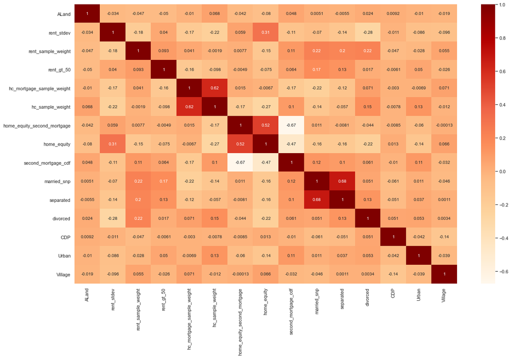

```python
heatmap(20,12,x_new.drop('const',axis=1))
```

> No High Correlation can be seen among the independent variables.

### Residual Analysis

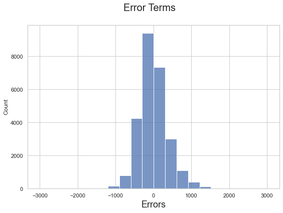

```python
y_train_price = lm_new.predict(x_new)
fig = plt.figure(figsize=(9,6))
sns.histplot((y_train - y_train_price), bins = 20)
fig.suptitle('Error Terms', fontsize = 20)                  # Plot heading
plt.xlabel('Errors', fontsize = 18)
plt.show()
```

> Error terms are distributed around zero which signifies that model prediction is not by chance.

# Making Predictions

```python
df_test.head()
```

|  | lat | lng | ALand | AWater | pop | male_pop | female_pop | rent_mean | rent_median | rent_stdev | rent_sample_weight | rent_samples | rent_gt_10 | rent_gt_15 | rent_gt_20 | rent_gt_25 | rent_gt_30 | rent_gt_35 | rent_gt_40 | rent_gt_50 | universe_samples | used_samples | hi_mean | hi_median | hi_stdev | hi_sample_weight | hi_samples | family_mean | family_median | … |
| --- | --- | --- | --- | --- | --- | --- | --- | --- | --- | --- | --- | --- | --- | --- | --- | --- | --- | --- | --- | --- | --- | --- | --- | --- | --- | --- | --- | --- | --- | --- |
| 258 | 17.97 | -66.61 | 3,946,834.00 | 5093745 | 4688 | 2211 | 2477 | 739.91 | 773.00 | 186.38 | 299.30 | 375.00 | 1.00 | 1.00 | 0.91 | 0.91 | 0.77 | 0.77 | 0.77 | 0.77 | 546 | 319 | 32,024.03 | 23,941.00 | 39,369.65 | 1,527.39 | 1,876.00 | 40,845.84 | 31,971.00 | … |
| 1820 | 17.99 | -67.00 | 58,350,923.00 | 11638620 | 2775 | 1482 | 1293 | 322.09 | 370.00 | 114.74 | 54.00 | 54.00 | 1.00 | 1.00 | 0.72 | 0.72 | 0.36 | 0.36 | 0.00 | 0.00 | 456 | 25 | 16,491.31 | 11,541.00 | 21,924.03 | 860.31 | 1,030.00 | 18,143.80 | 13,337.00 | … |
| 2377 | 18.00 | -65.90 | 1,719,472.00 | 510893 | 1619 | 841 | 778 | 390.41 | 351.00 | 175.32 | 187.00 | 187.00 | 0.89 | 0.73 | 0.67 | 0.57 | 0.48 | 0.35 | 0.29 | 0.21 | 214 | 183 | 32,243.21 | 18,621.00 | 49,395.47 | 467.08 | 582.00 | 39,619.13 | 24,122.00 | … |
| 6492 | 18.00 | -66.64 | 1,352,126.00 | 5489 | 3882 | 1660 | 2222 | 536.13 | 561.00 | 261.69 | 252.53 | 291.00 | 0.86 | 0.86 | 0.80 | 0.71 | 0.60 | 0.41 | 0.37 | 0.26 | 425 | 291 | 29,110.73 | 19,385.00 | 28,481.82 | 1,168.48 | 1,446.00 | 33,874.30 | 26,649.00 | … |
| 9871 | 18.01 | -66.63 | 526,009.00 | 0 | 3509 | 1580 | 1929 | 288.67 | 158.00 | 359.09 | 545.51 | 744.00 | 0.93 | 0.88 | 0.83 | 0.74 | 0.66 | 0.52 | 0.45 | 0.43 | 990 | 579 | 13,305.79 | 8,187.00 | 24,384.75 | 1,066.48 | 1,364.00 | 16,915.91 | 9,560.00 | … |

```python
final_features = list(x_new.columns)
final_features.remove('const')
print('The final features: ',final_features)
```

```
The final features:  ['ALand', 'rent_stdev', 'rent_sample_weight', 'rent_gt_50', 'hc_mortgage_sample_weight', 'hc_sample_weight', 'home_equity_second_mortgage', 'home_equity', 'second_mortgage_cdf', 'married_snp', 'separated', 'divorced', 'CDP', 'Urban', 'Village']
```

### Using our model to make predictions.

```python
x_test_new = x_test.filter(final_features) # keeping the significant features only
x_test_new = sm.add_constant(x_test_new) # Adding a constant variable
y_pred = lm_new.predict(x_test_new) # Making predictions
```

## Model Evaluation

#### Calculating the R-squared score on the test dataset

```python
from sklearn.metrics import r2_score
r2 = r2_score(y_test, y_pred)
log("R-square calculated for test data is : "+str(r2))
```

> R-square calculated for test data is : 0.6141441062716384

#### Plotting test vs. predicted to understand the spread.

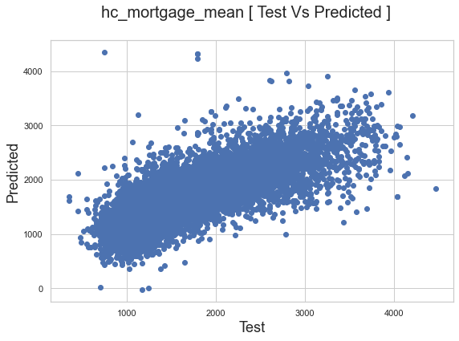

```python
fig = plt.figure(figsize=(9,6))
plt.scatter(y_test,y_pred)
fig.suptitle('hc_mortgage_mean [ Test Vs Predicted ]', fontsize=20)              # Plot heading
plt.xlabel('Test', fontsize=18)                          # X-label
plt.ylabel('Predicted', fontsize=18)                          # Y-label
plt.show()
```

### **Test if predicted variable is normally distributed**

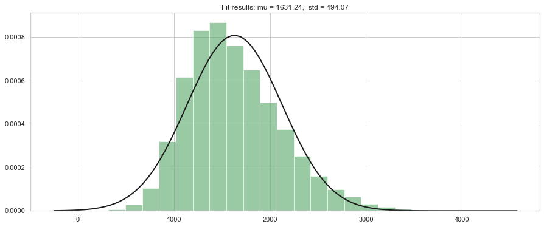

```python
data = y_pred.values.reshape(-1,1)
import numpy as np
from scipy.stats import norm
import matplotlib.pyplot as plt

# Fitting a normal distribution to the data:
mu, std = norm.fit(data)

# Plot the histogram.
plt.figure(figsize = (15,6))
plt.hist(data, bins=25, density=True, alpha=0.6, color='g')

# Plot the PDF.
xmin, xmax = plt.xlim()
x = np.linspace(xmin, xmax, 100)
p = norm.pdf(x, mu, std)
plt.plot(x, p, 'k', linewidth=2)
title = "Fit results: mu = %.2f,  std = %.2f" % (mu, std)
plt.title(title)

plt.show()
```

> Our predicted values are almost normally distributed

#### Mean and standard error of the predictor

```python
from numpy import mean
from numpy import std
print('mean=%.3f stdv=%.3f' % (mean(data), std(data)))
```

```
mean=1631.245 stdv=494.073
```

# Final Model Summary (Test Data)

```python
lm_test = sm.OLS(y_test,x_test_new).fit()
print(lm_test.summary())
```

```
                            OLS Regression Results
==============================================================================
Dep. Variable:       hc_mortgage_mean   R-squared:                       0.616
Model:                            OLS   Adj. R-squared:                  0.615
Method:                 Least Squares   F-statistic:                     1220.
Date:                Tue, 20 Jul 2021   Prob (F-statistic):               0.00
Time:                        16:11:25   Log-Likelihood:                -84597.
No. Observations:               11441   AIC:                         1.692e+05
Df Residuals:                   11425   BIC:                         1.693e+05
Df Model:                          15
Covariance Type:            nonrobust
===============================================================================================
                                  coef    std err          t      P>|t|      [0.025      0.975]
-----------------------------------------------------------------------------------------------
const                        1608.9010     23.473     68.542      0.000    1562.889    1654.913
ALand                       -2.853e-08   4.98e-09     -5.731      0.000   -3.83e-08   -1.88e-08
rent_stdev                      1.4131      0.022     64.289      0.000       1.370       1.456
rent_sample_weight             -0.1924      0.014    -13.304      0.000      -0.221      -0.164
rent_gt_50                   -240.2205     28.037     -8.568      0.000    -295.178    -185.263
hc_mortgage_sample_weight      -0.7103      0.026    -27.546      0.000      -0.761      -0.660
hc_sample_weight               -0.1260      0.027     -4.632      0.000      -0.179      -0.073
home_equity_second_mortgage -3004.3019    180.048    -16.686      0.000   -3357.226   -2651.378
home_equity                  2657.8470     68.431     38.840      0.000    2523.710    2791.983
second_mortgage_cdf          -146.6000     18.309     -8.007      0.000    -182.489    -110.711
married_snp                   501.9004    141.576      3.545      0.000     224.388     779.413
separated                   -2276.2935    246.682     -9.228      0.000   -2759.833   -1792.754
divorced                    -2417.8761     83.115    -29.091      0.000   -2580.796   -2254.956
CDP                          -121.1158     11.050    -10.961      0.000    -142.775     -99.457
Urban                        -145.2434     32.522     -4.466      0.000    -208.992     -81.495
Village                      -141.9143     11.787    -12.040      0.000    -165.019    -118.810
==============================================================================
Omnibus:                     1354.746   Durbin-Watson:                   1.785
Prob(Omnibus):                  0.000   Jarque-Bera (JB):             5323.585
Skew:                           0.548   Prob(JB):                         0.00
Kurtosis:                       6.157   Cond. No.                     5.54e+10
==============================================================================

Notes:
[1] Standard Errors assume that the covariance matrix of the errors is correctly specified.
[2] The condition number is large, 5.54e+10. This might indicate that there are
strong multicollinearity or other numerical problems.
```

> R-sqaured for train and test data are 61% each which means 61% variability is explained and no over and underfitting.

> F-stats and Prob(F-stats) (overall model fit) are 1220 and approx. 0 respectively which means Model fit is significant and explained 61% variance which is not random.

> p-values for the coefficients are less than the significance level of 5%, which means all the predictors are statistically significant.

> As per final model attributes which are best suited for predicting **The mean Monthly Mortgage and Owner Costs** are:  
> 1. The Square area of land.
> 1. The standard deviation of the gross rent.
> 2. The sum of gross rent weight used in calculations.
> 3. The empirical distribution value that an individual’s rent will be greater than 50% of their household income in the past 12 months.
> 4. The number of samples used in the statistical calculations.
> 5. The samples used in the calculation of the Monthly Owner Costs statistics.
> 6. % of houses with a second mortgage and home equity loan.
> 7. % of houses with a home equity loan.
> 8. Cumulative distribution value of one minus the percentage of homes with a second mortgage.
> 9. Marital status of the borrower.
> 10. Type of the location (CDP, Urban, Village)  
>     </span>